# Table of Contents

## Descomponer en factores primos

```python
#Creado por Andrés Melgar

#para iterando++ http://iterando.online/

#entrada: http://iterando.online/ejercicios-resueltos/descomposicion-en-factores-primos-en-python/

import math

def es_primo(n):

    if n <= 0:

        return False

    cant_divisores = 0

    encontro_divisores = False

    limite=math.sqrt(n)

    i = 2

    while i <= limite and not encontro_divisores:

        if n % i == 0:

            cant_divisores+=1

            encontro_divisores = True

        i+=1

    if cant_divisores==0 and n>1:

        return True

    return False


def siguiente_primo(n):

    while True:

        n+=1

        if es_primo(n):

            return n


def escribe_factor(hay_factores, factor_primo, cant_factores):

    if cant_factores > 0:

        if hay_factores:

            print("x", end="")

        else:

            hay_factores = True

        if cant_factores==1:

            print(factor_primo, end="")

        else:

            print("{:d}^{:d}".format(factor_primo, cant_factores), end="")

        cant_factores = 0

        return hay_factores, cant_factores

def descomponer_factores(n):

    productoria = 1

    copia_n = n

    factor_primo = 2

    cant_factores = 0

    hay_factores = False

    while True:

        resto = copia_n % factor_primo

        if resto == 0:

            copia_n //= factor_primo

            productoria *= factor_primo

            cant_factores += 1

        else:

            if cant_factores > 0:

                hay_factores, cant_factores = escribe_factor(hay_factores, factor_primo, cant_factores)

            factor_primo = siguiente_primo(factor_primo)



        if productoria == n:

            break;

    escribe_factor(hay_factores, factor_primo, cant_factores)

n = int(input("Ingrese un número (>1): "))

if n <= 1:

    print("Debe ingresar un número mayor que uno")

else:

    descomponer_factores(n)
```

```
Ingrese un número (>1): 46
2x23
```

## Listar números primos

```python
primos = [2]
nmax = 30
for x in range(3, nmax):
    for i in range(2, x):
        if x%i != 0:
            # Si i no es divisor de x, x puede ser primo
            continue
        else:
            # Si i es divisor de x, x no es primo
            break #No es necesario buscar más divisores
    else:
        # El bucle for ha terminado con normalidad
        # El número que estábamos comprobando es primo
        print (f"El número {x} es primo")

        primos.append(x)
F = open('numerosprimos.txt', 'w')
for data in primos:
    F.write('%d\n'%data)
```

## Teorema de pitágoras

```python
from math import sqrt
try:
    input = raw_input
except NameError:
    pass
def get_numeric_value(prompt):
    """
    Solicita un valor numérico de la entrada estándar.
    Devuelve None si no se introduce ningún valor.
    """
    while True:
        value = input(prompt)
        if not value:
            return None
        try:
            value = int(value)
        except ValueError:
            print("Debe ingresar un valor numerico. "
                      "Vuelva a intentarlo.")
        else:
            break
    return value

def get_triangle(a=None, b=None, h=None):
    """
    Devuelve un triángulo formado con guiones, con los valores especificados..
    """
    return r"""
        |\
        | \
        |  \ h
      a |   \
        |    \
        |_ _ _\
          b

    a = %s
    b = %s
    h = %s""" % ("?" if a is None else a,
                     "?" if b is None else b,
                     "?" if h is None else h)
def main():
    print(get_triangle())
    print("\nDeje en blanco el valor que desconoce.\n")

    a = get_numeric_value("a: ")
    b = get_numeric_value("b: ")

    if a is None or b is None:
        h = get_numeric_value("h: ")
    else:
        h = None

    if (bool(a) + bool(b) + bool(h)) < 2:
        print("Debe especificar, al menos, dos valores.")
        return 0

    if h is None:
        h = sqrt(a**2 + b**2)
    elif a is None:
        a = sqrt(h**2 - b**2)
    elif b is None:
        b = sqrt(h**2 - a**2)

    print("")
    print(get_triangle(a, b, h))

    return 0
if __name__ == '__main__':
    main()
```

## [Operaciones con Polinomios](https://github.com/algoritmosmathpy/algoritmos-python/blob/master/Operaciones%20entre%20dos%20Polinomios.py)

```python
"""
Algortimo para la resolucion de operaciones entre 2 polinomios
Ejercicio: Resolver la siguiente multiplicación de polinomios
P(x) = 7*x**3 + 2*x**2 + x - 7
Q(x) = x**2 + 3
"""

#Importamos la libreria SympY para usar variables simbolicas (x, y)
import sympy

#Obtenes los dos polinomios introducidos por el usuario
P1 = input("Primer Polinomio: ")
P2 = input("Segundo Polinomio: ")
print("\n")

#Definimos los simbolos
sympy.init_printing()
x,y = sympy.symbols('x,y')

#Luego almacenamos en varibles los dos polinomios procesados por la funcion Poly de sympy
Poly1 = sympy.Poly(P1)
Poly2 = sympy.Poly(P2)

#Declaramos una funcion para cada operacion que queramos utilizar

def mult(p1, p2):
    return p1 * p2

def suma(p1, p2):
    return p1 + p2

def res(p1, p2):
    return p1 - p2

def div(p1, p2):
    return p1 / p2

#Guardamos los valores retornados por las funciones y les pasamos los 2 polinomios como parametros,  Poly1 y Poly2
resultMult = mult(Poly1, Poly2)
resultSuma = suma(Poly1, Poly2)
resultDiv = div(Poly1, Poly2)
resultRes = res(Poly1, Poly2)

#Mostramos el valor que deseemos
print("Resultado: ", resultMult)
```

## Sistemas de ecuaciones

Ejemplo:

$2x+4y+6z = 18 \quad 4x+5y+6z = 24 \quad 3x+y-2z=4$

```python
import numpy as np
a = np.array([[2, 4, 6], [4,5, 6], [3, 1, -2]])
b = np.array([18, 24, 4])
x = np.linalg.solve(a, b)

print (f"Las soluciones son: x = {round(x[0],2)}, y = {round(x[1],2)} y z = {round(x[2], 2)}")
```

## Ecuaciones de segundo grado

```python
from math import sqrt

A = int(input("Ingrese el coeficiente de la variable cuadrática\n"))
B = int(input("Ingrese el coeficiente de la variable lineal\n"))
C = int(input("Ingrese el término independiente\n"))
x1 = 0
x2 = 0

if ((B**2)-4*A*C) < 0:
    print("La solución de la ecuación es con números complejos")
else:
    x1 = (-B+sqrt(B**2-(4*A*C)))/(2*A)
    x2 = (-B-sqrt(B**2-(4*A*C)))/(2*A)
    print(f"Las soluciones de la ecuación son: x1 = {round(x1,2)} y x2 = {round(x2,2)}")
```

```python
from math import sqrt

class Ecuaciones2Grado():

    def __init__(self):
        self.interfaz()

    def calcular(self, A, B, C):
        if ((B**2)-4*A*C) < 0:
            print("La solución de la ecuación es con números complejos")
        else:
            x1 = (-B+sqrt(B**2-(4*A*C)))/(2*A)
            x2 = (-B-sqrt(B**2-(4*A*C)))/(2*A)
            print(f"\nLas soluciones de la ecuación son: x1 = {round(x1,2)} y x2 = {round(x2,2)} " )

    def interfaz(self):

        A = int(input("Ingrese el coeficiente de la variable cuadrática\n"))
        B = int(input("Ingrese el coeficiente de la variable lineal\n"))
        C = int(input("Ingrese el término independiente\n"))


objeto = Ecuaciones2Grado()
objeto.calcular(A, B, C)
```

## [Sistemas de ecuaciones lineales con dos incógnitas](https://elbauldelprogramador.com/como-resolver-sistemas-de-ecuaciones-lineales-con-dos-incognitas/)

```python
a = 3
b = 4
c = 5
d = 1
e = 2
f = 6

det = a * e - b * d

if det != 0 :
    x = (e * c - b * f) / det
    y = (a * f - d * c) / det

    print (f"La solucion al sistema es x = {round(x, 2)} e y =  {round(y,2)}")

else :
    m = d / a

    if m * c == f :
        print ("El sistema tiene infinitas soluciones")
    else:
        print ("El sistema no tiene soluciones")
```

# Areas y volúmenes

## Areas y volúmenes de figuras planas (2D)

### Area del cuadrado

$P = 4a \quad \quad A = a²$

```python
# Area del cuadrado

def cuadrado(x):
    a = float(input("Introduzca el valor del lado del cuadrado:  "))
    A = a * a
    P = 4 * a

    print(f"\nEl peráimetro del cuadrado de lado {a} es {P}")
    print(f"\nEl area del cuadrado de lado {a} es {A}")

cuadrado(0)
```

### Area del rectángulo

$P = 2 (b+h) \quad \quad A = b \cdot h$

```python
# Area del rectángulo
def rectangulo(x):
    b = float(input("Introduzca el largo del Rectangulo "))
    h = float(input("\nIntroduzca el ancho del rectangulo "))
    A = b * h

    P = 2*b + 2*h

    print(f"\nEl perímetro de un rectángulo de largo {b} y ancho {h} es {P}" )
    print(f"\nEl area de un rectángulo de largo {b} y ancho {h} es {A}" )

rectangulo(0)
```

### Area del rombo

$P = 4a = 4 \sqrt{ \left ( \frac{d}{2} \right )² + \left ( \frac{D}{2} \right )²} \quad \quad A = \frac{D \cdot d}{2}$

```python
import math
# Area del rombo
def rombo(x):
    D = float(input("Introduzca la diagonal mayor: "))
    d = float(input("Introduzca la diagonal menor: "))
    # Cálculo del área
    A = (D * d)/ 2
    # Cálculo del perímetro.
    P = 4 * math.sqrt((D/2)**2 + (d/2)**2)
    # Cálculo del valor de un lado
    a = math.sqrt((D/2)**2 + (d/2)**2)

    print (f"El lado del rombo mide: {a}")
    print (f"El perímetro del rombo es: {P}")
    print (f"El área del rombo es: {A}")

rombo(0)
```

```python
        |\
        | \
        |  \ h
      a |   \
        |    \
        |_ _ _\
          b
```

```python
     /|\
    / | \
 a /  |  \a
  /   | h \
 /    |    \
/_____|_____\
```

### Area del triángulo equilátero

$P = 3a \quad \quad A = \frac{a \cdot h}{2}$

```python
 # Area del triángulo equilátero
def triangulo(x):
    a = float(input("Introduzca el valor de la base: "))
    #h = float(input("\nIntroduzca el valor de la altura: "))
    h = sqrt( a**2 - (a/2)**2 )
    # Cálculo del área
    A = (a * h)/2
    # Cálculo del perímetro
    P = 3 * a

    print(f"\nLa altura del triangulo equilátero es {h}")
    print(f"\nEl área del triangulo equilátero es {A}")
    print(f"\nEl perímetro del triangulo equilátero es {P}")
triangulo(0)
```

### Area del triángulo isósceles

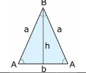

$P = 2 \cdot a + b \quad \quad A = \frac{b \cdot h}{2}$

```python
import math
# Area del triángulo isósceles
def triangulo(x):
    b = float(input("Introduzca el valor de la base\n"))
    h = float(input("Introduzca el valor de la altura\n"))

    # Cálcuo del área
    A = (b*h)/2

    # Cálculo del perímetro
    a = math.sqrt((b/2)**2 + h**2)
    P = 2*a + b

    print(f"El perímetro del triangulo es {P}")
    print(f"El area del triangulo es {A}")

triangulo(0)
```

### Area del triángulo escaleno

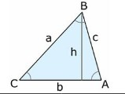

$P = a + b + c \quad \quad A = \frac{b \cdot h}{2}$

```python
 # Area del triángulo escaleno
def triangulo(x):
    b = float(input("Introduzca el valor de la base:"))
    h = float(input("Introduzca el valor de la altura: "))
    #a = float(input("Introduzca el valor del lado a: "))
    #c = float(input("Introduzca el valor del lado b: "))

    # Cálculo del área
    A = (b*h)/2

    # Cálculo del perímetro
    #P = a+b+c
    #print(f"El perímetro del triangulo es {P}")
    print(f"El area del triangulo es {A}")

triangulo(0)
```

### Area del romboide

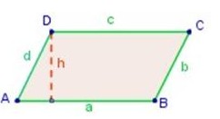

```python
# Area del romboide
def romboide(x):
    a = float(input("introduzca el valor de la base: "))
    h = float(input("introduzca el valor de la altura: "))
    A = a*h
    print(f"el area de el romboide es: {A}")

romboide(0)
```

### Area del trapecio

$P = a + B + c + d \quad \quad A = \frac{B + b}{2} \cdot h$

```python
import math
def trapecio(x):
    B = float(input("Introduzca el valor de la base menor: "))
    b = float(input("\nIntroduzca el valor de la base mayor: "))
    h = float(input("\nIntroduzca el valor de la altura: "))
    A = ((B + b) / 2 ) * h

    print(f"El area del trapecio es {A}")

trapecio(0)
```

### Area del pentágono rectangular

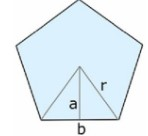

$P = 5 \cdot b \quad \quad A = \frac {p \cdot a}{2}$

```python
# Area del pentágono rectangular
# Area del exágono rectangular
def poligono(x):
    a = float(input("Introduzca el valor de la Apotema\n"))
    b = float(input("\nIntroduzca el valor de la base\n"))
    P = 5 * b
    A = (P * b) / 2

    print(f"\nEl area del Poligono Rectangular es {A} ")

poligono(0)
```

### Area del exágono regular

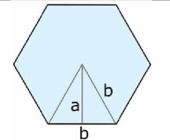

$ p = 6 * b \quad \quad A = \frac {p \cdot a}{2}$

```python
# Area del exágono rectangular
def poligono(x):
    a = float(input("Introduzca el valo de la Apotema\n"))
    b = float(input("\nIntroduzca el valor de la base\n"))
    P = 6 * b
    A = (P * b) / 2

    print(f"\nEl area del Poligono Rectangular es {A} ")

poligono(0)
```

### Area del círculo

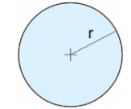

$P = 2 \pi r \quad \quad A = \pi \cdot r²$

```python
def circulo(x):
    r = float(input("Introduzca el valor del Radio:\n"))
    A = (math.pi*(r**2))
    P = 2*math.pi*r

    print(f"El area del circulo es: {A}" )
    print(f"El perímetro del circulo es: {P}")
circulo(0)
```

### Area de la corona circular

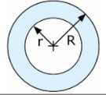

$P = 2 \pi (R + r) \quad \quad A = \pi (R² - r²)$

```python
# Area de la corona circular
def corona(x):
    R  = float(input("Introduzca el valor del Radio mayor\n"))
    r = float(input("Introduzca el valor del radio menor\n"))
    A = math.pi*((R**2)-(r**2))
    P = 2*pi*(R+r)

    print(f"El area de la corona es {A})
corona(0)
```

### Area del sector circular

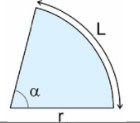

$L = \pi r \frac{\alpha}{180} \quad \quad A = \pi r² \frac{\alpha}{360}$

```python
#Area del sector circular
def sector(x):
    # Area del sector
    n = float(input("Introduzca el valor del angulo: "))
    r = float(input("introduzca el valor del radio: "))
    A = math.pi*(r**2)*n /360

    # Longitud del arco

    L = math.pi * r * n / 180

    print(f"La longitud del arco es {L}")
    print(f"El valor del area es {A}")
sector(0)
```

## Areas y volúmenes de figuras en el espacio (3D)

## Area y volúmen del cubo

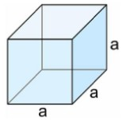

$A = 6 \cdot a² \quad \quad V = a³$

```python
import math
# Area y volúmen del cubo
def cubo(x):
    a = float(input("Introduzca el valor del lado: "))
    A = 6*(a**2)
    V = (a**3)
    print("\nEl area del cubo es: ",A)
    print("\nEl volumen del cubo es: ",V,"\n")

cubo(0)
```

## Area y volúmen del cilindro

$Al = 2 \cdot \pi \cdot r \cdot h \quad \quad At = 2\cdot \pi \cdot r (r+h) \quad \quad V = \pi \cdot r² \cdot h$

```python
import math
# Areas y volúmen del cilindro
def cilindro(x):
    r = float(input("\nIntroduzca el radio del cilindro "))
    h = float(input("\nIntroduzca la altura del cilindro "))
    Alat = 2*(math.pi)*r*h
    Atot = (2*(math.pi)*(h+r))
    V = (math.pi*(r**2)*h)
    print(f"\nEl area lateral del  cilindro es { Alat}")
    print(f"\nEl area total del  cilindro es {Atot}")
    print(f"\nEl volumen del cilindro es {V}")
cilindro(0)
```

## Area y volúmen del ortoedro

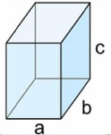

$Al = 2 (a \cdot b + b \cdot c + a \cdot c) \quad \quad V = a \cdot b \cdot c$

```python
# Area y volúmen del ortoedro
import math
def ortoedro(x):
    a = float(input("Introduzca el valor del ancho: "))
    b = float(input("\nIntroduzca el valor del largo: "))
    c = float(input("\nintroduzca el valor de la altura: "))
    Al = 2*((a*b)+(b*c)+(a*c))
    V = a*b*c
    print(f"\nEl area lareral del Ortoedro es {Al}")
    print(f"\nEl volumen del ortoedro es {V}")
ortoedro(0)
```

## Area y volúmen del cono

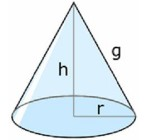

$Al = \pi \cdot r \cdot g \quad \quad g = \sqrt{h² + r²} \quad \quad At = \pi \cdot r (r + g) \quad \quad V = \frac {1}{3} \cdot \pi \cdot r² \cdot h$

```python
# Area y volúmen del cono
import math
def cono(x):
    g = float(input("Introduzca la generatriz del cono"))
    h = float(input("Introduzca la altura del cono"))
    r = float(input("introduzca el radio del cono"))
    Al = math.pi * r * g
    At = (math.pi*r)*(g+r)
    V = (math.pi*(r**2)*h)/3

    print(f"\nEl area lateral del cono es {Al}")
    print(f"\nEl area total del cono es {At}")
    print(f"\nEl volumen del cono es {V}")
cono(0)
```

## Area y volúmen del prisma recto

$A = 2 \cdot A_b + n \cdot A_l \quad \quad V = A_b \cdot h$

```python
# Area y volúmen del prisma recto.
import math
def prisma(x):
    A = float(input("Introduzca el Apotema: "))
    l = float(input("introduzca el lado: "))
    h = float(input("introduzca la altura: "))
    a = l*(h+A)
    V = ((l*A)/2)*h
    print("El area del prisma recto es:  ",A,"\n")
    print("El area del prisma recto es:  ",V,"\n")
prisma(0)
```

## Area y volúmen del tronco de cono

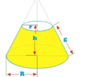

$ A_l = \pi \cdot (R + r) \cdot g \quad \quad A_t = \pi \cdot [(R + r) \cdot g + R² + r²] \quad \quad V = \frac {1}{3} \cdot \pi \cdot h (R² + r² + R \cdot r)$

```python
# Area y volúmen del tronco de cono
import math
def tronco(x):
    h = float(input("Introduzca la altura\n"))
    r = float(input("Introduzca el Radio Menor"))
    R = float(input("Introduzca el Radio Mauyor"))
    g = float(input("Introduzca la generatriz"))
    Al = math.pi *(R*r)*g
    At = math.pi*[(R+r) * g + R**2 +r**2]
    V = (math.pi*h*((R**2)+(r**2)+(R*r)))/3
    print(f"\nEl volumen del tronco de cono es: {V}")
    print(f"\nEl area lateral del tronco de cono es: {Al}")
    print(f"\nEl area total del tronco de cono es: {At}")

tronco(0)
```

## Area y volúmen del tetaedro regular.

```python
import math
# Area y volúmen del tetaedro regular
import math
def teatredo(x):
    a = float(input("Introduzca el lado"))
    h = float(input("Introduzca la altura"))
    A = math.sqrt(3) * a**2
    V = (math.sqrt(3)/12) * a**3
    print(f"El area del tetaedro es: {A}")
    print(f"El volumen del tetaedro es: {V}")
teatredo(0)
```

```
Introduzca el lado12
Introduzca la altura23
El area del tetaedro es: 249.4153162899183
El volumen del tetaedro es: 249.4153162899183
```

## Area y volumen del octaedro

$A = 2 \cdot \sqrt{3 } \cdot a² \quad \quad V = \frac {\sqrt{2}}{3} \cdot a³$

```python
# Area y volúmen del octaedro
import math
def octaedro(x):
    l=float(input("Introduzca el lado : "))
    a=2*(l**2)*math.sqrt(3)
    print("El area del octaedro es: ",a,"\n")
octaedro(0)
```

## Area y volúmen de la esfera

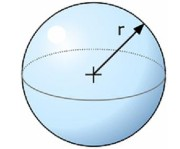

```python
# Area y volúmen de la esfera
import math
def esfera(x):
    r=float(input("Introduzca el radio: "))
    A=math.pi*4*(r**2)
    V=(math.pi*4*(r**2))/3
    print(f"El area de la esfera es: {A}")
    print(f"El volumen de la esfera es: {V}")
esfera(0)
```

```
Introduzca el radio: 12
El area de la esfera es: 1809.5573684677208
El volumen de la esfera es: 603.1857894892403
```

## Area y volúmen del huso

```python
# Area y volúmen del huso
import math
def huso(x):
    n = float(input("Introduzca el angulo: "))
    r = float(input("Introduzva el radio: "))
    a = (4*math.pi*(r**2)*n)/360
    v = (4*math.pi*(r**3)*n)/(360*3)
    print("El area es: ",a,"\n")
    print("El volumen es : ",v,"\n")
huso(0)
```

## Area y volúmen de la pirámide

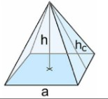

$A_l = \frac {Perimetro_{base} \cdot h_c}{2} \quad \quad A_t = A_l + A_{base} \quad \quad V = \frac {1}{3} \quad A_{base} \cdot h$

```python
# Area y volúmen de la pirámide
import math
def piramide(x):
    b = float(input("Introduzca el Apotema de la base: "))
    c = float(input("Introduzca el Apotema de base triangular: "))
    l = float(input("Introduzca el Lado de la base: "))
    h = float(input("Introduzca la altura: "))
    a = ((4*l)*(b+c))/2
    v = ((l**2)*h)/3
    print("El area es: ",a,"\n")
    print("El Volumen es: ",v,"\n")
piramide(0)
```

## Area y volúmen del casquete

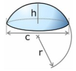

$ A_{lat} = 2 \cdot \pi \cdot r \cdot h = \frac {\pi}{4} ( c² + 4 \cdot h²)$

$A_{base} = \frac {\pi \cdot c²}{4} \quad \quad r = \frac {h}{2} + \frac {c²}{8h}$

```python
# Area y volúmen del casquete
import math
def casquete(x):
    r = float(input("introduzca el radio:"))
    h = float(input("Introduzca la altura"))
    A = 2*math.pi*r*h
    V = math.pi*(h**2)*((3*r)-h)
    print(f"El area del casquete es: {A}")
    print(f"El volumen del casquete es: {V}")
casquete(0)
```

```
introduzca el radio:125
Introduzca la altura12
El area del casquete es: 9424.77796076938
El volumen del casquete es: 164217.33118844568
```

## Area del tronco de pirámide

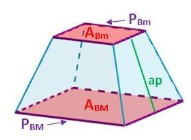

$A_{lat} = \frac {(A_{BM} + A_{Bm}) \cdot g} {2}$

$ V = \frac {h (\cdot(A_{BM} + A_{Bm} + \sqrt {A_{BM} \cdot A_{Bm}})}{3}$

```python
# Area del tronco de pirámide
import math
def tronpi(x):
    l = float(input("introduzca el lado de base menor"))
    L = float(input("Introduzca el lado de base mayor"))
    H = float(input("Introduzca la altura del trapezio"))
    h = float(input("introduzca la altura del tronco de la piramide"))
    A = ((4*L)+(4*l))*H+(L**2)+(l**2)
    V = (h*((L**2)+(l**2) + math.sqrt((L**2)(l**2))))/3
    print("El area del tronco de pirámide es: {A}")
    print("El volumen del tronco de pirámide es: {V}")

tronpi(0)
```

```
introduzca el lado de base menor12
Introduzca el lado de base mayor56
Introduzca la altura del trapezio87
introduzca la altura del tronco de la piramide45
```

[output not shown]

```python
V = (h*((L**2)+(l**2) + math.sqrt((L**2)(l**2))))/3
```

## Area y volúmen del casquete esférico o zona esférica

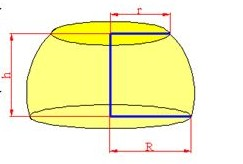

$V = \frac{1}{3} \pi \cdot h (3 \cdot R \cdot h - h²)$

```python
# Area y volúmen de la zona esférica.
import math
def zona(x):
    h = float(input("Introduzca la altura"))
    r = float(input("Introduzca el radio"))
    a = 2*math.pi*r*h
    v = math.pi*h*((h**2)+(3*(r**3))+(3*(r**2)))
    print("El area es: ",a,"\n")
    print("El volumen es: ",v,"\n")
zona(0)
```

https://calculo.cc/temas/temas_trigonometria/trian_semejante/problemas/p_area_vol_1.html

```python
lista_nombres = ["Pepe", "Luis", "Jaime"]

for counter, value in enumerate(lista_nombres):
    print(counter, value)
print ("\t20 - Salir")
# solicitamos una opción de valor al usuario
opcion_val = int (input("\nSeleccione un valor  \n") )

    if opcion_val == 20:
        #raise SystemExit
        #sys.exit()
        exit()

    if opcion_val >= 20 :
        input("\nNo has pulsado ninguna opción correcta...\npulsa una tecla para continuar\n")
```